# report

#### crim ~ zn

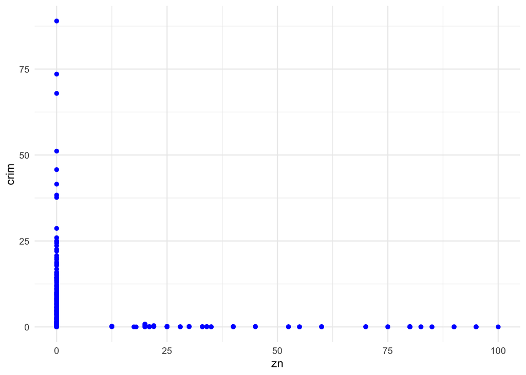

```r
ggplot(Boston, aes(x = zn, y = crim)) +
  geom_point(color = "blue") +
  theme_minimal()
```

zn의 경우, 데이터가 편향되어 있기 때문에 crim의 predictor로 사용하기 어려워 보인다.

#### crim ~ dis

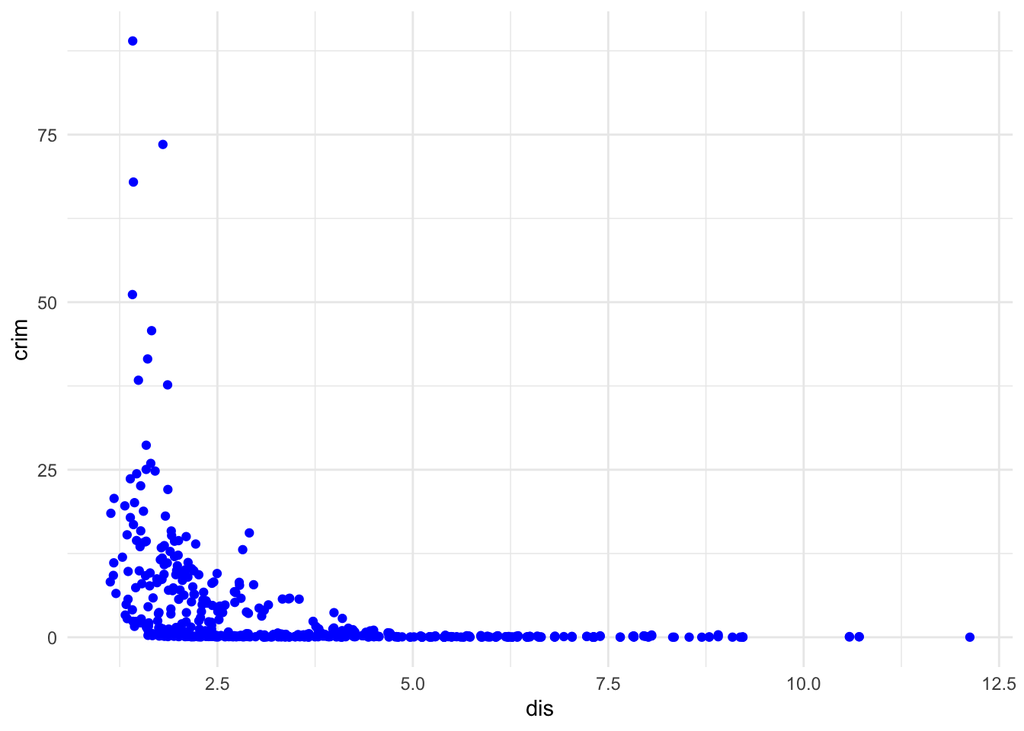

```r
ggplot(Boston, aes(x = dis, y = crim)) +
  geom_point(color = "blue") +
  theme_minimal()
```

#### crim ~ rad

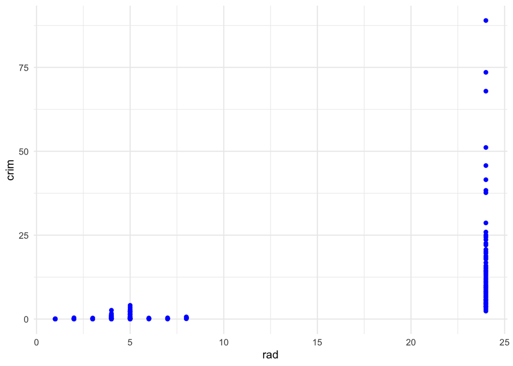

```r
ggplot(Boston, aes(x = rad, y = crim)) +
  geom_point(color = "blue") +
  theme_minimal()
```

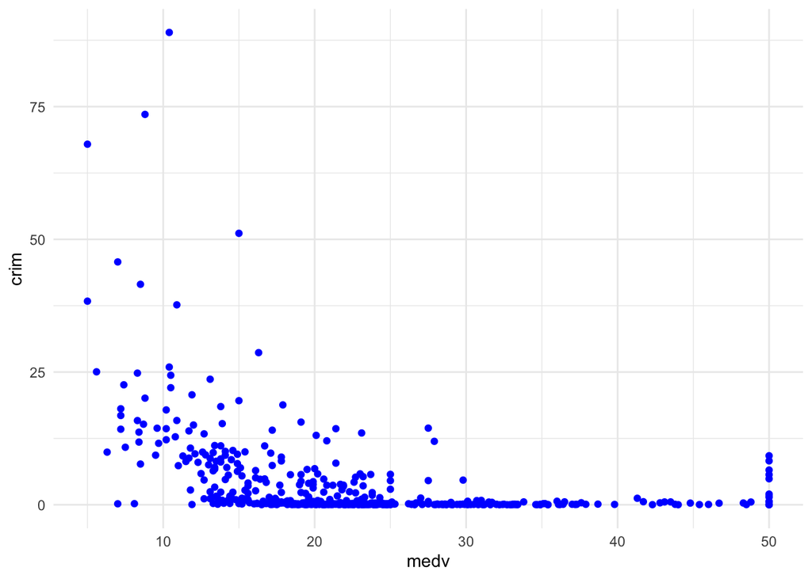

```r
ggplot(Boston, aes(x = medv, y = crim)) +
  geom_point(color = "blue") +
  theme_minimal()
```

linear model을 통해서 zn, dis, rad, medv 라는 predictor를 선택했지만, scatter plot을 그려본 결과, zn은 적절하지 않다고 판단하여, crim 예측변수로 dis, rad, medv를 사용하기로 한다.

### (a) Split the data set into a training set and a test set.

```r
set.seed(123)

split = initial_split(Boston, prop = 0.75)

train_data_boston = training(split)
test_data_boston = testing(split)

print(nrow(train_data_boston))
```

```
## [1] 379
```

```r
print(nrow(test_data_boston))
```

```
## [1] 127
```

### (b) Fit a linear model using least squares on the training set, and report the test error obtained.

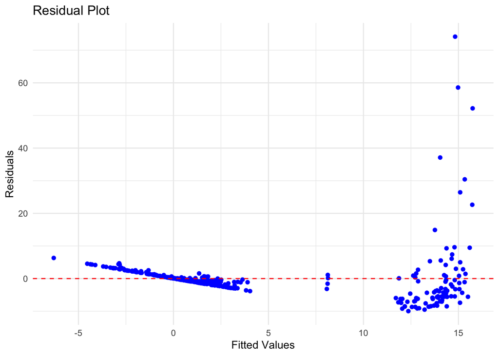

```r
linear_model_boston = lm(crim ~ dis + rad + medv, data = train_data_boston)

residuals_boston = resid(linear_model_boston)
fitted_values_boston = fitted(linear_model_boston)

residual_data_boston = data.frame(Fitted = fitted_values_boston, Residuals = residuals_boston)

ggplot(residual_data_boston, aes(x = Fitted, y = Residuals)) +
  geom_point(color = "blue") +
  geom_hline(yintercept = 0, linetype = "dashed", color = "red") +
  labs(title = "Residual Plot",
       x = "Fitted Values",
       y = "Residuals") +
  theme_minimal()
```

```r
summary(linear_model_boston)
```

```
##
## Call:
## lm(formula = crim ~ dis + rad + medv, data = train_data_boston)
##
## Residuals:
##    Min     1Q Median     3Q    Max
## -9.984 -1.805 -0.604  0.818 74.152
##
## Coefficients:
##             Estimate Std. Error t value Pr(>|t|)
## (Intercept)  3.52069    1.55934   2.258   0.0245 *
## dis         -0.31035    0.19829  -1.565   0.1184
## rad          0.56347    0.05174  10.891  < 2e-16 ***
## medv        -0.17117    0.04338  -3.946 9.48e-05 ***
## ---
## Signif. codes:  0 '***' 0.001 '**' 0.01 '*' 0.05 '.' 0.1 ' ' 1
##
## Residual standard error: 7.163 on 375 degrees of freedom
## Multiple R-squared:  0.4169, Adjusted R-squared:  0.4122
## F-statistic: 89.36 on 3 and 375 DF,  p-value: < 2.2e-16
```

R-squared가 0.4169로 설명력이 다소 떨어지는 것을 확인할 수 있다. 이는 outlier의 영향이라고 해석된다. outlier를 제거하는 과정을 거치게 되면, 더 높은 R-squared 값을 얻을 수 있을 것이라 예상된다.

#### test error

```r
y_pred_boston = predict(linear_model_boston, newdata = test_data_boston)
test_data_boston = test_data_boston %>% mutate(y_pred_boston)

residuals_boston = test_data_boston$crim - y_pred_boston
RSS_boston = sum(residuals_boston^2)
MSE_linear_model_boston = mean((test_data_boston$crim - y_pred_boston)^2)

print(RSS_boston)
```

```
## [1] 2486.926
```

```r
print(MSE_linear_model_boston)
```

```
## [1] 19.58209
```

RSS : 2486.926  
MSE : 19.58209

### (c) Fit a ridge regression model on the training set, with $\lambda$ chosen by cross-validation. Report the test error obtained, along with the number of non-zero coefficient estimates.

```r
x_train_boston = model.matrix(crim ~ dis + rad + medv, data = train_data_boston)[, -1]
y_train_boston = train_data_boston$crim

x_test_boston = model.matrix(crim ~ dis + rad + medv, data = test_data_boston)[, -1]
y_test_boston = test_data_boston$crim

ridge_cv_boston = cv.glmnet(x_train_boston, y_train_boston, alpha = 0)
optimal_lambda_b = ridge_cv_boston$lambda.min
optimal_lambda_b
```

```
## [1] 0.5806559
```

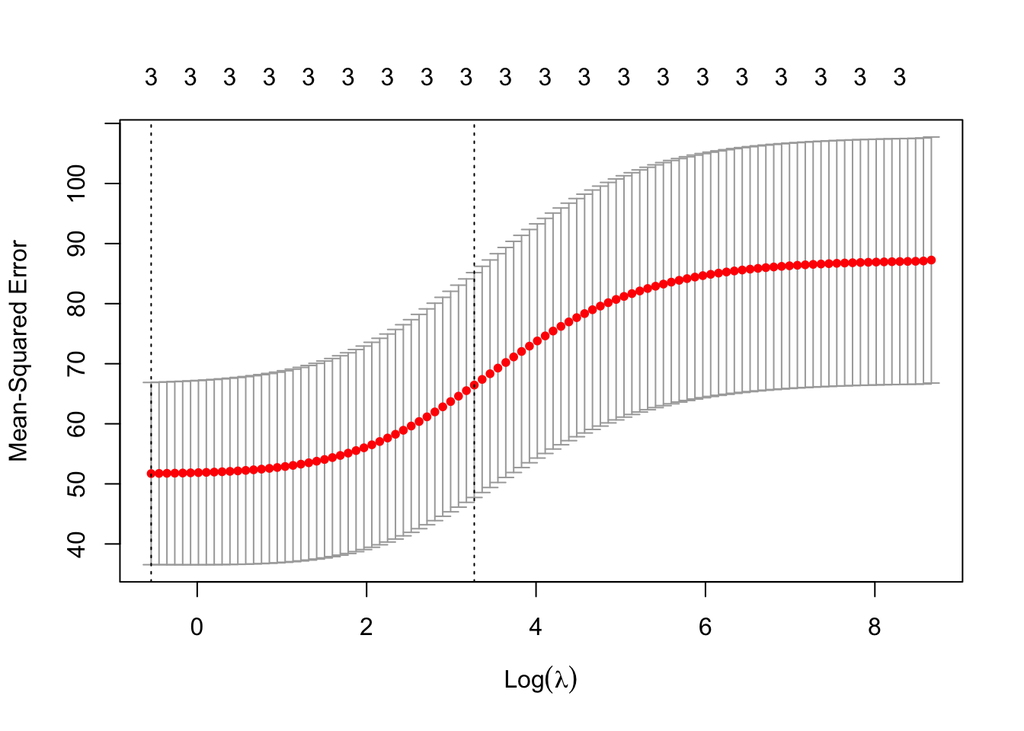

```r
plot(ridge_cv_boston)
```

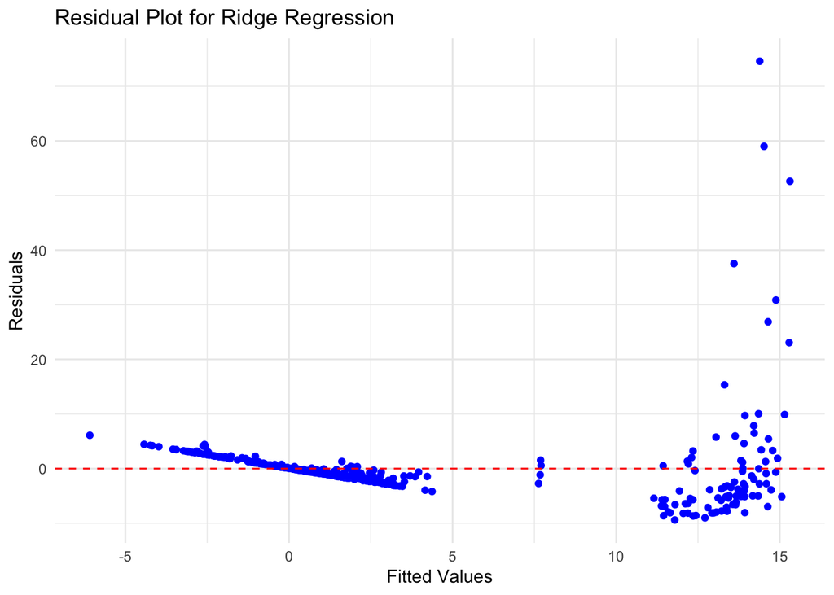

```r
ridge_model_b = glmnet(x_train_boston, y_train_boston, alpha = 0, lambda = optimal_lambda_b)

fitted_values_b <- predict(ridge_model_b, s = optimal_lambda_b, newx = x_train_boston)
residuals_b <- y_train_boston - fitted_values_b

# 데이터프레임 생성
residual_data_b <- data.frame(Fitted = fitted_values_b, Residuals = residuals_b)

# 잔차 플롯 그리기
ggplot(residual_data_b, aes(x = s1, y = s1.1)) +
  geom_point(color = "blue") +
  geom_hline(yintercept = 0, linetype = "dashed", color = "red") +
  labs(title = "Residual Plot for Ridge Regression",
       x = "Fitted Values",
       y = "Residuals") +
  theme_minimal()
```

```r
y_pred_b = predict(ridge_model_b, s = optimal_lambda_b, newx = x_test_boston)
```

```r
MSE_b = mean((y_test_boston - y_pred_b)^2)
print(MSE_b)
```

```
## [1] 18.64452
```

```r
print(MSE_linear_model_boston)
```

```
## [1] 19.58209
```

```r
print(MSE_b - MSE_linear_model_boston)
```

```
## [1] -0.937577
```

MSE_ridge_model : 18.64452  
MSE_linear_model : 19.58209  
MSE-ridge_model - MSE_linear_model : -0.937577  
근소한 차이로 ridge regression model의 MSE 가 linear model보다 더 작다는 것을 확인했다.  
따라서, Boston data set의 경우, ridge regression model이 linear regression model 보다 약간 더 나은 성능을 보인다고 결론을 내릴 수 있다.

### (e) Comment on the results obtained. How accurately can we predict the crim? Is there much difference among the test errors resulting from these five approaches?

```r
RSS_boston = sum((y_test_boston - y_pred_b)^2)
TSS_boston = sum((y_test_boston - mean(y_test_boston))^2)
r_squared_ridge_boston = 1 - RSS_boston/TSS_boston
r_squared_ridge_boston
```

```
## [1] 0.4504118
```

linear model squared r : 0.4169  
ridge model squared r : 0.4504118

모델의 설명력 또한 ridge model이 더 높게 나온 것을 확인할 수 있었다.